# Исследование объявлений о продаже квартир

# Содержание

## Описание проекта

В этом проекте проводится исследование объявлений о продаже квартир в Санкт-Петербурге и его окрестностях.

**Основные задачи**:

- научиться определять рыночную стоимость объектов недвижимости
- определить, какие параметры и как влияют на итоговую цену объекта
- подготовить сами данные и выводы, сделанные в ходе исследования, для построения автоматизированной системы, которая сможет отслеживать аномалии и мошенническую деятельность

**План работы**:

- открытие и знакомство с данными
- предобработка данных
- подготовка данных для передачи их специалисту data science для построения автоматизированной системы, отслеживающей аномалии и мошеннической деятельности
- исследовательский анализ данных, визуализация данных
- общий вывод и рекомендации

**Описание данных**:

Данные предоставлены сервисом Яндекс Недвижимость, это архив объявлений о продаже квартир в Санкт-Петербурге и соседних населённых пунктах за несколько лет.

По каждой квартире на продажу доступны два вида данных. Первые вписаны пользователем, вторые — получены автоматически на основе картографических данных (например, расстояние до центра, аэропорта, ближайшего парка и водоёма).

## Открытие и изучение данных

```python
import pandas as pd
import os
import matplotlib.pyplot as plt
```

```python
df = pd.read_csv('/datasets/real_estate_data.csv', sep='\t')
```

```python
if os.path.exists('/datasets/real_estate_data.csv'):
    df = pd.read_csv('/datasets/real_estate_data.csv', sep='\t')
else:
    df = pd.read_csv('/C:/datasets/real_estate_data.csv', sep='\t')
```

Для проверки данных использую собственную функцию:

```python
def my_check_function (dataset):
    '''Функция для ознакомления и проверки даных'''
    print('Как выглядят случайные 5 строк:')
    display(dataset.sample(5, random_state=42))
    print()
    print('Общая информация о данных, наименования столбцов, типы данных:')
    print(dataset.info())
    print()
    print('Есть ли пропуски, сколько их:')
    print(dataset.isna().sum())
    print('Доля пропущенных значений:')
    print(dataset.isna().mean())
    print()
    print('Есть ли явные дубликаты, сколько их:')
    print(dataset.duplicated().sum())
    print('Доля явных дубликатов:')
    print(dataset.duplicated().mean())
    print()
    print('Подробное описание данных:')
    display(dataset.describe())
```

```python
my_check_function(df)
```

```
Как выглядят случайные 5 строк:
```

|  | total_images | last_price | total_area | first_day_exposition | rooms | ceiling_height | floors_total | living_area | floor | is_apartment | ... | kitchen_area | balcony | locality_name | airports_nearest | cityCenters_nearest | parks_around3000 | parks_nearest | ponds_around3000 | ponds_nearest | days_exposition |
| --- | --- | --- | --- | --- | --- | --- | --- | --- | --- | --- | --- | --- | --- | --- | --- | --- | --- | --- | --- | --- | --- |
| 7944 | 14 | 2990000.0 | 35.0 | 2019-03-29T00:00:00 | 1 | NaN | 17.0 | 16.0 | 10 | NaN | ... | 9.0 | NaN | Мурино | NaN | NaN | NaN | NaN | NaN | NaN | NaN |
| 7539 | 8 | 3790000.0 | 33.0 | 2018-12-18T00:00:00 | 1 | 2.50 | 7.0 | 18.0 | 2 | NaN | ... | 5.6 | NaN | Санкт-Петербург | 27455.0 | 8621.0 | 1.0 | 217.0 | 0.0 | NaN | 90.0 |
| 9889 | 1 | 12990000.0 | 191.0 | 2017-08-31T00:00:00 | 7 | 3.30 | 5.0 | 136.1 | 2 | NaN | ... | 16.0 | 0.0 | Санкт-Петербург | 26856.0 | 5704.0 | 0.0 | NaN | 1.0 | 1017.0 | 77.0 |
| 649 | 1 | 7210000.0 | 61.5 | 2018-10-02T00:00:00 | 3 | 2.92 | 5.0 | 43.2 | 4 | NaN | ... | 5.7 | 1.0 | Санкт-Петербург | 25407.0 | 3982.0 | 1.0 | 483.0 | 0.0 | NaN | 89.0 |
| 13768 | 10 | 550000.0 | 36.0 | 2017-08-22T00:00:00 | 1 | NaN | 2.0 | 20.0 | 1 | NaN | ... | 8.0 | 0.0 | Сланцы | NaN | NaN | NaN | NaN | NaN | NaN | 92.0 |

5 rows × 22 columns

```
Общая информация о данных, наименования столбцов, типы данных:
<class 'pandas.core.frame.DataFrame'>
RangeIndex: 23699 entries, 0 to 23698
Data columns (total 22 columns):
 #   Column                Non-Null Count  Dtype
---  ------                --------------  -----
 0   total_images          23699 non-null  int64
 1   last_price            23699 non-null  float64
 2   total_area            23699 non-null  float64
 3   first_day_exposition  23699 non-null  object
 4   rooms                 23699 non-null  int64
 5   ceiling_height        14504 non-null  float64
 6   floors_total          23613 non-null  float64
 7   living_area           21796 non-null  float64
 8   floor                 23699 non-null  int64
 9   is_apartment          2775 non-null   object
 10  studio                23699 non-null  bool
 11  open_plan             23699 non-null  bool
 12  kitchen_area          21421 non-null  float64
 13  balcony               12180 non-null  float64
 14  locality_name         23650 non-null  object
 15  airports_nearest      18157 non-null  float64
 16  cityCenters_nearest   18180 non-null  float64
 17  parks_around3000      18181 non-null  float64
 18  parks_nearest         8079 non-null   float64
 19  ponds_around3000      18181 non-null  float64
 20  ponds_nearest         9110 non-null   float64
 21  days_exposition       20518 non-null  float64
dtypes: bool(2), float64(14), int64(3), object(3)
memory usage: 3.7+ MB
None

Есть ли пропуски, сколько их:
total_images                0
last_price                  0
total_area                  0
first_day_exposition        0
rooms                       0
ceiling_height           9195
floors_total               86
```

[output cut: 32 more lines]

```
airports_nearest        0.233850
cityCenters_nearest     0.232879
parks_around3000        0.232837
parks_nearest           0.659100
ponds_around3000        0.232837
ponds_nearest           0.615596
days_exposition         0.134225
dtype: float64

Есть ли явные дубликаты, сколько их:
0
Доля явных дубликатов:
0.0

Подробное описание данных:
```

|  | total_images | last_price | total_area | rooms | ceiling_height | floors_total | living_area | floor | kitchen_area | balcony | airports_nearest | cityCenters_nearest | parks_around3000 | parks_nearest | ponds_around3000 | ponds_nearest | days_exposition |
| --- | --- | --- | --- | --- | --- | --- | --- | --- | --- | --- | --- | --- | --- | --- | --- | --- | --- |
| count | 23699.000000 | 2.369900e+04 | 23699.000000 | 23699.000000 | 14504.000000 | 23613.000000 | 21796.000000 | 23699.000000 | 21421.000000 | 12180.000000 | 18157.000000 | 18180.000000 | 18181.000000 | 8079.000000 | 18181.000000 | 9110.000000 | 20518.000000 |
| mean | 9.858475 | 6.541549e+06 | 60.348651 | 2.070636 | 2.771499 | 10.673824 | 34.457852 | 5.892358 | 10.569807 | 1.150082 | 28793.672193 | 14191.277833 | 0.611408 | 490.804555 | 0.770255 | 517.980900 | 180.888634 |
| std | 5.682529 | 1.088701e+07 | 35.654083 | 1.078405 | 1.261056 | 6.597173 | 22.030445 | 4.885249 | 5.905438 | 1.071300 | 12630.880622 | 8608.386210 | 0.802074 | 342.317995 | 0.938346 | 277.720643 | 219.727988 |
| min | 0.000000 | 1.219000e+04 | 12.000000 | 0.000000 | 1.000000 | 1.000000 | 2.000000 | 1.000000 | 1.300000 | 0.000000 | 0.000000 | 181.000000 | 0.000000 | 1.000000 | 0.000000 | 13.000000 | 1.000000 |
| 25% | 6.000000 | 3.400000e+06 | 40.000000 | 1.000000 | 2.520000 | 5.000000 | 18.600000 | 2.000000 | 7.000000 | 0.000000 | 18585.000000 | 9238.000000 | 0.000000 | 288.000000 | 0.000000 | 294.000000 | 45.000000 |
| 50% | 9.000000 | 4.650000e+06 | 52.000000 | 2.000000 | 2.650000 | 9.000000 | 30.000000 | 4.000000 | 9.100000 | 1.000000 | 26726.000000 | 13098.500000 | 0.000000 | 455.000000 | 1.000000 | 502.000000 | 95.000000 |
| 75% | 14.000000 | 6.800000e+06 | 69.900000 | 3.000000 | 2.800000 | 16.000000 | 42.300000 | 8.000000 | 12.000000 | 2.000000 | 37273.000000 | 16293.000000 | 1.000000 | 612.000000 | 1.000000 | 729.000000 | 232.000000 |
| max | 50.000000 | 7.630000e+08 | 900.000000 | 19.000000 | 100.000000 | 60.000000 | 409.700000 | 33.000000 | 112.000000 | 5.000000 | 84869.000000 | 65968.000000 | 3.000000 | 3190.000000 | 3.000000 | 1344.000000 | 1580.000000 |

На всякий случай продублируем "сырые" данные, чтобы в дальнейшем, после изменений, можно было сравнить два датасета.

```python
df_raw = pd.read_csv('/datasets/real_estate_data.csv', sep='\t')
```

### Вывод

Данные содержат множество параметров (**22 столбца**) и достаточно большой массив информации (**23699 строки**).

**Наименование столбцов** подобрано разумно, проблем со стилем заполнения в целом нет, но я бы исправила некоторые моменты:

- cityCenters_nearest - city_centers_nearest (везде без исключений будет "змеиный регистр");
- studio - is_studio,
- open_plan - is_open_plan (по аналогии с is*apartment, столбцы с булевым типом данных, их наименование начать с "is*").

**Типы данных** в некоторых случаях, возможно, следует изменить.

- first_day_exposition изменить на datetime
- is_apartment - должен быть тип данных bool

Столбцы с типом данных float64, которые хотелось бы видеть в формате int64:

- last_price
- floors_total
- balcony
- airports_nearest
- cityCenters_nearest
- parks_around3000
- parks_nearest
- ponds_around3000
- ponds_nearest
- days_exposition

С точки зрения здравого смысла значения в этих столбцах логичнее было бы видеть в формате целого числа (например, что около дома 1 или 2 парка, но не 1.5 или 1.7; или что этажей в доме 15 или 16, а не 15.5). Но, возможно, это связано с технической причиной, например, с пропусками. Следует с этим разобраться на этапе предобработки данных (после осмотра пропусков).

В данных есть **пропуски**, в некоторых разделах их очень много. Есть столбцы, где доля пропущенных значений составляет **менее 10%**:

- locality_name 0.002068
- floors_total 0.003629
- living_area 0.080299
- kitchen_area 0.096122

А есть столбцы, где такая доля **выше 10%** и значение доходит даже **до 88%**:

- days_exposition 0.134225
- parks_around3000 0.232837
- ponds_around3000 0.232837
- cityCenters_nearest 0.232879
- airports_nearest 0.233850
- ceiling_height 0.387991
- balcony 0.486054
- ponds_nearest 0.615596
- parks_nearest 0.659100
- is_apartment 0.882906

**Явных дубликатов** в данных нет.

В подробном описании данных можно заметить **артефакты**:

- ceiling_height: минимальное значение 1м, максимальное значение 100м.
- living_area: минимальное значение 2кв.м.

## Предобработка данных

Заменим наименования некоторых столбцов:

```python
df = df.rename(columns={'cityCenters_nearest':'city_centers_nearest', 'studio':'is_studio',
'open_plan':'is_open_plan'})
```

Теперь детальнее рассмотрим **пропуски**.

Столбцы, где доля пропущенных значений составляет менее 10% (в скобках указано количество пропусков):

- locality_name (49)
- floors_total (86)
- living_area (1903)
- kitchen_area (2278)

Такое количество пропусков не является критичным.

А вот столбцы, где доля пропусков выше (от 13 до 88%), уже вызывают больше вопросов:

- days_exposition (3181)
- parks_around3000 (5518)
- ponds_around3000 (5518)
- city_centers_nearest (5519)
- airports_nearest (5542)
- ceiling_height (9195)
- balcony (11519)
- ponds_nearest (14589)
- parks_nearest (15620)
- is_apartment (20924)

**Возможные причины** появления **пропусков**:

- не все графы при заполнении данных об объекте недвижимости являются обязательными, и клиенты заполняют только самую необходимую информацию (например, оставляя пропущенным графу о балконе, если его нет)
- клиенты не знают некоторую техническую информацию о своём объекте (например, высота потолков, точная площадь кухни)
- имеет место человеческий фактор (например, вовремя не поступила информация о том, сколько дней было размещено объявление от публикации до снятия)
- возможны технические ошибки или сбои (например, настораживает одинаковое число пропусков в столбцах 'parks_around3000' и 'ponds_around3000')
- возможны сложности с получением автоматических картографических данных в некоторых населённых пунктах или районах
- также сложно может быть клиенту самому указать, каково расстояние в метрах от его до объекта недвижимости до пруда, парка или аэропорта
- возможно пропуски имеют намеренный характер (например, клиент не указывает, что объект имеет статус апартаментов, чтобы продать объект по более высокой цене; или не указывает название населённого пункта, если объект находится на стыке города и пригорода и относится к пригороду).

В большинстве случаев заполнить эти пропуски - значит буквально досочинить то, чего нет, а это, в свою очередь, негативно отразится на объективности данных. Поэтому за редким исключением данные оставлю в том же виде, в котором они находятся.

**Какие пропуски можно заполнить**:

- balcony (вероятнее всего, эту графу пропускали те, у кого нет балкона - ведь если бы он был, это было бы преимуществом для объекта недвижимости и не было бы смысла это преимущество не показывать в своём объявлении). Пропуски можно заполнить значением 0.
- ceiling_height (вероятно, многим клиентам не известна точная информация о высоте потолков и неудобно её мерять самостоятельно; зато во многих случаях дома могут быть типовыми, соответственно можно попробовать заменить пропуски средним значением в самых многочисленных категориях - например, в 5, 9, -этажных домах). Пропуски можно заменить медианой в зависимости от значения в столбце floors_total

Заполняем пропуски нулями:

```python
df['balcony'] = df['balcony'].fillna(0)
```

Проверяем: пропусков больше нет.

```python
df['balcony'].isna().sum()
```

```
0
```

Посмотрим, дома с каким количеством этажей самые многочисленные:

```python
df['floors_total'].value_counts().head(10)
```

```
5.0     5788
9.0     3761
16.0    1376
12.0    1362
4.0     1200
10.0    1174
25.0    1075
6.0      914
17.0     833
3.0      668
Name: floors_total, dtype: int64
```

Заполним пропуски для самых многочисленных категорий домов (возьмём значения больше 1000): это 5, 9, 16, 12, 4, 10, 25 -этажные дома. Вероятно, раз они более многочисленные, они имеют более типовой, повторяющийся вид (в отличие от домов с нестандартной этажностью, которые могут быть частями индивидуальных архитектурных проектов, и достоверно заменить пропуски для таких домов будет сложнее).

Зафиксируем, сколько пропусков было:

```python
df['ceiling_height'].isna().sum()
```

```
9195
```

Проводим заполнение выбранных пропусков медианой:

```python
my_median_5 = df.loc[df['floors_total'] == 5.0, 'ceiling_height'].median()
```

```python
df.loc[(df['floors_total'] == 5.0) & (df['ceiling_height'].isna()), 'ceiling_height'] = my_median_5
```

```python
my_median_9 = df.loc[df['floors_total'] == 9.0, 'ceiling_height'].median()
```

```python
df.loc[(df['floors_total'] == 9.0) & (df['ceiling_height'].isna()), 'ceiling_height'] = my_median_9
```

```python
my_median_16 = df.loc[df['floors_total'] == 16.0, 'ceiling_height'].median()
```

```python
df.loc[(df['floors_total'] == 16.0) & (df['ceiling_height'].isna()), 'ceiling_height'] = my_median_16
```

```python
my_median_12 = df.loc[df['floors_total'] == 12.0, 'ceiling_height'].median()
```

```python
df.loc[(df['floors_total'] == 12.0) & (df['ceiling_height'].isna()), 'ceiling_height'] = my_median_12
```

```python
my_median_4 = df.loc[df['floors_total'] == 4.0, 'ceiling_height'].median()
```

```python
df.loc[(df['floors_total'] == 4.0) & (df['ceiling_height'].isna()), 'ceiling_height'] = my_median_4
```

```python
my_median_10 = df.loc[df['floors_total'] == 10.0, 'ceiling_height'].median()
```

```python
df.loc[(df['floors_total'] == 10.0) & (df['ceiling_height'].isna()), 'ceiling_height'] = my_median_10
```

```python
my_median_25 = df.loc[df['floors_total'] == 25.0, 'ceiling_height'].median()
```

```python
df.loc[(df['floors_total'] == 25.0) & (df['ceiling_height'].isna()), 'ceiling_height'] = my_median_25
```

Посмотрим, сколько пропусков осталось. Количество пропусков существенно снизилось.

```python
df['ceiling_height'].isna().sum()
```

```
3462
```

С пропусками разобрались. Теперь рассмотрим типы данных.

Переводим значения столбца 'first_day_exposition' в формат datetime:

```python
df['first_day_exposition'] = pd.to_datetime(
df['first_day_exposition'], format='%Y-%m-%dT%H:%M:%S')
```

В столбце 'last_price' тип данных изменяем на целое число:

```python
df['last_price'] = df['last_price'].astype('int')
```

Остальные столбцы с типом данных float64, которые хотелось бы видеть в формате целого числа:

- floors_total
- balcony
- airports_nearest
- city-centers_nearest
- parks_around3000
- parks_nearest
- ponds_around3000
- ponds_nearest
- days_exposition

а также

- is apartament (тип object, хотя предполагается тип данных bool) - все они имеют пропуски типа NaN, поэтому здесь такой "некрасивый" тип данных (который кажется нелогичным с общечеловеческой точки зрения), но зато с ним можно будет проводить математические операции (поэтому нет смысла его изменять).

Теперь приглядимся к **артефактам**. Во время знакомства с данными были замечены следующие аномалии:

- ceiling_height: минимальное значение 1м, максимальное значение 100м.
- living_area: минимальное значение 2кв.м.

```python
df.loc[df['ceiling_height'] < 2]
```

|  | total_images | last_price | total_area | first_day_exposition | rooms | ceiling_height | floors_total | living_area | floor | is_apartment | ... | kitchen_area | balcony | locality_name | airports_nearest | city_centers_nearest | parks_around3000 | parks_nearest | ponds_around3000 | ponds_nearest | days_exposition |
| --- | --- | --- | --- | --- | --- | --- | --- | --- | --- | --- | --- | --- | --- | --- | --- | --- | --- | --- | --- | --- | --- |
| 5712 | 5 | 1500000 | 42.8 | 2017-08-14 | 2 | 1.20 | 2.0 | 27.5 | 1 | NaN | ... | 5.20 | 0.0 | городской посёлок Мга | NaN | NaN | NaN | NaN | NaN | NaN | 248.0 |
| 16934 | 5 | 4100000 | 40.0 | 2017-10-17 | 1 | 1.75 | 37.0 | 17.4 | 5 | NaN | ... | 8.34 | 0.0 | Санкт-Петербург | 18732.0 | 20444.0 | 0.0 | NaN | 3.0 | 80.0 | 71.0 |
| 22590 | 16 | 6000000 | 55.0 | 2018-10-31 | 2 | 1.00 | 12.0 | 32.4 | 7 | NaN | ... | 10.00 | 0.0 | Санкт-Петербург | 33053.0 | 14217.0 | 2.0 | 293.0 | 2.0 | 289.0 | 13.0 |

3 rows × 22 columns

Такую высоту потолка для жилого помещения сложно себе представить, возможно, это опечатка. Другие данные из этих строк могут быть полезны, поэтому удалять строки не хочется. Скорее всего, эти артефакты являются опечаткой (вместо 1 должна быть 2), можно их исправить (3 строки данные не исказят).

Посмотрим ради проверки:

```python
df['ceiling_height'].value_counts()
```

```
2.55    4306
2.50    3515
2.70    2085
2.60    2070
3.00    1523
        ...
5.00       1
2.20       1
4.15       1
3.93       1
3.59       1
Name: ceiling_height, Length: 183, dtype: int64
```

Разных значений было 183.

Исправляем опечатку:

```python
df.loc[df['ceiling_height'] < 2, 'ceiling_height'] = df.loc[df['ceiling_height'] < 2, 'ceiling_height'] + 1
```

Снова проверяем:

```python
df['ceiling_height'].value_counts()
```

```
2.55    4306
2.50    3515
2.70    2085
2.60    2070
3.00    1523
        ...
4.65       1
5.00       1
4.15       1
3.93       1
3.59       1
Name: ceiling_height, Length: 180, dtype: int64
```

Разных значений стало 180, другие данные не изменились

Проверяем: артефактов больше нет:

```python
df.loc[df['ceiling_height'] < 2]
```

|  | total_images | last_price | total_area | first_day_exposition | rooms | ceiling_height | floors_total | living_area | floor | is_apartment | ... | kitchen_area | balcony | locality_name | airports_nearest | city_centers_nearest | parks_around3000 | parks_nearest | ponds_around3000 | ponds_nearest | days_exposition |
| --- | --- | --- | --- | --- | --- | --- | --- | --- | --- | --- | --- | --- | --- | --- | --- | --- | --- | --- | --- | --- | --- |

0 rows × 22 columns

Теперь посмотрим на строки с информацией об объектах, где высота потолка более 10 метров:

```python
df.loc[df['ceiling_height'] > 10]
```

|  | total_images | last_price | total_area | first_day_exposition | rooms | ceiling_height | floors_total | living_area | floor | is_apartment | ... | kitchen_area | balcony | locality_name | airports_nearest | city_centers_nearest | parks_around3000 | parks_nearest | ponds_around3000 | ponds_nearest | days_exposition |
| --- | --- | --- | --- | --- | --- | --- | --- | --- | --- | --- | --- | --- | --- | --- | --- | --- | --- | --- | --- | --- | --- |
| 355 | 17 | 3600000 | 55.2 | 2018-07-12 | 2 | 25.0 | 5.0 | 32.0 | 2 | False | ... | NaN | 2.0 | Гатчина | NaN | NaN | NaN | NaN | NaN | NaN | 259.0 |
| 3148 | 14 | 2900000 | 75.0 | 2018-11-12 | 3 | 32.0 | 3.0 | 53.0 | 2 | NaN | ... | 8.0 | 0.0 | Волхов | NaN | NaN | NaN | NaN | NaN | NaN | NaN |
| 4643 | 0 | 4300000 | 45.0 | 2018-02-01 | 2 | 25.0 | 9.0 | 30.0 | 2 | NaN | ... | 7.0 | 1.0 | Санкт-Петербург | 12016.0 | 13256.0 | 1.0 | 658.0 | 1.0 | 331.0 | 181.0 |
| 4876 | 7 | 3000000 | 25.0 | 2017-09-27 | 0 | 27.0 | 25.0 | 17.0 | 17 | NaN | ... | NaN | 2.0 | посёлок Мурино | NaN | NaN | NaN | NaN | NaN | NaN | 28.0 |
| 5076 | 0 | 3850000 | 30.5 | 2018-10-03 | 1 | 24.0 | 5.0 | 19.5 | 1 | True | ... | 5.5 | 0.0 | Санкт-Петербург | 29686.0 | 8389.0 | 3.0 | 397.0 | 1.0 | 578.0 | 7.0 |
| 5246 | 0 | 2500000 | 54.0 | 2017-10-13 | 2 | 27.0 | 5.0 | 30.0 | 3 | NaN | ... | 9.0 | 2.0 | деревня Мины | NaN | NaN | NaN | NaN | NaN | NaN | 540.0 |
| 5669 | 4 | 4400000 | 50.0 | 2017-08-08 | 2 | 26.0 | 9.0 | 21.3 | 3 | NaN | ... | 7.0 | 2.0 | Санкт-Петербург | 28981.0 | 10912.0 | 1.0 | 305.0 | 0.0 | NaN | 267.0 |
| 5807 | 17 | 8150000 | 80.0 | 2019-01-09 | 2 | 27.0 | 36.0 | 41.0 | 13 | NaN | ... | 12.0 | 5.0 | Санкт-Петербург | 18732.0 | 20444.0 | 0.0 | NaN | 3.0 | 80.0 | 38.0 |
| 6246 | 6 | 3300000 | 44.4 | 2019-03-25 | 2 | 25.0 | 5.0 | 31.3 | 5 | NaN | ... | 5.7 | 0.0 | Кронштадт | 68923.0 | 50649.0 | 1.0 | 417.0 | 2.0 | 73.0 | NaN |
| 9379 | 5 | 3950000 | 42.0 | 2017-03-26 | 3 | 25.0 | 5.0 | 30.0 | 2 | NaN | ... | 5.2 | 0.0 | Санкт-Петербург | 11647.0 | 13581.0 | 0.0 | NaN | 0.0 | NaN | NaN |
| 10773 | 8 | 3800000 | 58.0 | 2017-10-13 | 2 | 27.0 | 10.0 | 30.1 | 3 | False | ... | 8.1 | 2.0 | посёлок Мурино | NaN | NaN | NaN | NaN | NaN | NaN | 71.0 |
| 11285 | 0 | 1950000 | 37.0 | 2019-03-20 | 1 | 25.0 | 5.0 | 17.0 | 4 | False | ... | 9.0 | 2.0 | Луга | NaN | NaN | NaN | NaN | NaN | NaN | 18.0 |
| 14382 | 9 | 1700000 | 35.0 | 2015-12-04 | 1 | 25.0 | 5.0 | 20.0 | 2 | False | ... | 8.0 | 1.0 | поселок Новый Свет | NaN | NaN | NaN | NaN | NaN | NaN | 206.0 |
| 15061 | 19 | 5600000 | 56.4 | 2018-05-11 | 2 | 14.0 | 14.0 | 32.4 | 5 | NaN | ... | 9.1 | 2.0 | Санкт-Петербург | 14814.0 | 13610.0 | 0.0 | NaN | 0.0 | NaN | 315.0 |
| 17496 | 15 | 6700000 | 92.9 | 2019-02-19 | 3 | 20.0 | 17.0 | 53.2 | 14 | NaN | ... | 12.0 | 5.0 | Санкт-Петербург | 16295.0 | 15092.0 | 1.0 | 967.0 | 0.0 | NaN | NaN |
| 17857 | 1 | 3900000 | 56.0 | 2017-12-22 | 3 | 27.0 | 5.0 | 33.0 | 4 | False | ... | NaN | 0.0 | Санкт-Петербург | 41030.0 | 15543.0 | 0.0 | NaN | 0.0 | NaN | 73.0 |
| 18545 | 6 | 3750000 | 43.0 | 2019-03-18 | 2 | 25.0 | 5.0 | 29.0 | 3 | False | ... | NaN | 0.0 | Санкт-Петербург | 27054.0 | 8033.0 | 1.0 | 540.0 | 0.0 | NaN | 12.0 |
| 20478 | 11 | 8000000 | 45.0 | 2017-07-18 | 1 | 27.0 | 4.0 | 22.0 | 2 | NaN | ... | 10.0 | 1.0 | Санкт-Петербург | 18975.0 | 3246.0 | 0.0 | NaN | 3.0 | 449.0 | 429.0 |
| 20507 | 12 | 5950000 | 60.0 | 2018-02-19 | 2 | 22.6 | 14.0 | 35.0 | 11 | NaN | ... | 13.0 | 1.0 | Санкт-Петербург | 27028.0 | 12570.0 | 0.0 | NaN | 0.0 | NaN | 40.0 |
| 21377 | 19 | 4900000 | 42.0 | 2017-04-18 | 1 | 27.5 | 24.0 | 37.7 | 19 | False | ... | 11.0 | 2.0 | Санкт-Петербург | 42742.0 | 9760.0 | 0.0 | NaN | 0.0 | NaN | 61.0 |
| 21824 | 20 | 2450000 | 44.0 | 2019-02-12 | 2 | 27.0 | 2.0 | 38.0 | 2 | False | ... | 8.6 | 2.0 | городской поселок Большая Ижора | NaN | NaN | NaN | NaN | NaN | NaN | NaN |
| 22309 | 20 | 5300000 | 45.0 | 2017-09-30 | 1 | 10.3 | 16.0 | 15.5 | 15 | NaN | ... | NaN | 0.0 | Санкт-Петербург | 36353.0 | 11936.0 | 2.0 | 440.0 | 2.0 | 450.0 | 136.0 |
| 22336 | 19 | 9999000 | 92.4 | 2019-04-05 | 2 | 32.0 | 6.0 | 55.5 | 5 | False | ... | 16.5 | 4.0 | Санкт-Петербург | 18838.0 | 3506.0 | 0.0 | NaN | 3.0 | 511.0 | NaN |
| 22869 | 0 | 15000000 | 25.0 | 2018-07-25 | 1 | 100.0 | 5.0 | 14.0 | 5 | True | ... | 11.0 | 5.0 | Санкт-Петербург | 34963.0 | 8283.0 | 1.0 | 223.0 | 3.0 | 30.0 | 19.0 |
| 22938 | 14 | 4000000 | 98.0 | 2018-03-15 | 4 | 27.0 | 2.0 | 73.0 | 2 | True | ... | 9.0 | 1.0 | деревня Нижняя | NaN | NaN | NaN | NaN | NaN | NaN | 27.0 |

25 rows × 22 columns

Предположу, что вероятнее всего значения 25, 26, 27 - это опечатки от 2.5, 2.6, 2.7. Это нереалистичные значения, потому что, если взглянуть например на первую строку (индекс 355), то мы увидим, что помещение будто бы имеет высоту потолка 25 метров, при том что оно находится в 5-этажном доме (floors_total 5.0),тогда как высота типового 5-этажного дома составляет около 15 метров (и средняя высота потолков в таком доме как раз 2.5).

Исправляем аномалии для такхи случаев:

```python
df.loc[df['ceiling_height'] > 20, 'ceiling_height'] = df['ceiling_height'] * 0.1
```

Смотрим на оставшиеся строки:

```python
df.loc[df['ceiling_height'] > 10]
```

|  | total_images | last_price | total_area | first_day_exposition | rooms | ceiling_height | floors_total | living_area | floor | is_apartment | ... | kitchen_area | balcony | locality_name | airports_nearest | city_centers_nearest | parks_around3000 | parks_nearest | ponds_around3000 | ponds_nearest | days_exposition |
| --- | --- | --- | --- | --- | --- | --- | --- | --- | --- | --- | --- | --- | --- | --- | --- | --- | --- | --- | --- | --- | --- |
| 15061 | 19 | 5600000 | 56.4 | 2018-05-11 | 2 | 14.0 | 14.0 | 32.4 | 5 | NaN | ... | 9.1 | 2.0 | Санкт-Петербург | 14814.0 | 13610.0 | 0.0 | NaN | 0.0 | NaN | 315.0 |
| 17496 | 15 | 6700000 | 92.9 | 2019-02-19 | 3 | 20.0 | 17.0 | 53.2 | 14 | NaN | ... | 12.0 | 5.0 | Санкт-Петербург | 16295.0 | 15092.0 | 1.0 | 967.0 | 0.0 | NaN | NaN |
| 22309 | 20 | 5300000 | 45.0 | 2017-09-30 | 1 | 10.3 | 16.0 | 15.5 | 15 | NaN | ... | NaN | 0.0 | Санкт-Петербург | 36353.0 | 11936.0 | 2.0 | 440.0 | 2.0 | 450.0 | 136.0 |

3 rows × 22 columns

Для оставшихся данных однозначного объяснения нет, возможно, это ошибки, а может быть, и какие-то специфические объекты, занимающие несколько этажей. Остальные сведения из этих строк могут быть полезны, удалять их не буду.

Теперь посмотрим на строки с информацией об объектах, где жилая площадь менее 6 кв.м.:

```python
df.loc[df['living_area'] < 6]
```

|  | total_images | last_price | total_area | first_day_exposition | rooms | ceiling_height | floors_total | living_area | floor | is_apartment | ... | kitchen_area | balcony | locality_name | airports_nearest | city_centers_nearest | parks_around3000 | parks_nearest | ponds_around3000 | ponds_nearest | days_exposition |
| --- | --- | --- | --- | --- | --- | --- | --- | --- | --- | --- | --- | --- | --- | --- | --- | --- | --- | --- | --- | --- | --- |
| 3242 | 7 | 4440000 | 41.0 | 2017-07-02 | 1 | NaN | 17.0 | 3.0 | 17 | NaN | ... | 11.0 | 0.0 | Санкт-Петербург | 19272.0 | 13073.0 | 0.0 | NaN | 0.0 | NaN | 216.0 |
| 13915 | 20 | 6350000 | 52.0 | 2018-02-06 | 2 | 3.00 | 6.0 | 2.0 | 2 | NaN | ... | 9.0 | 0.0 | Санкт-Петербург | 32453.0 | 6521.0 | 0.0 | NaN | 1.0 | 1012.0 | 91.0 |
| 17582 | 11 | 2680000 | 22.0 | 2018-08-11 | 0 | 2.75 | 25.0 | 5.0 | 8 | NaN | ... | NaN | 2.0 | Санкт-Петербург | 22735.0 | 11618.0 | 1.0 | 835.0 | 1.0 | 652.0 | 70.0 |
| 21758 | 0 | 2330000 | 23.0 | 2018-01-01 | 0 | NaN | 24.0 | 2.0 | 22 | NaN | ... | NaN | 0.0 | посёлок Мурино | NaN | NaN | NaN | NaN | NaN | NaN | 66.0 |
| 21943 | 15 | 6100000 | 77.6 | 2019-02-28 | 4 | 2.50 | 9.0 | 5.4 | 1 | NaN | ... | 9.8 | 0.0 | Санкт-Петербург | 29338.0 | 11270.0 | 1.0 | 584.0 | 0.0 | NaN | 33.0 |
| 23574 | 14 | 64990000 | 139.0 | 2015-11-24 | 3 | 3.00 | 8.0 | 3.0 | 8 | NaN | ... | 16.0 | 1.0 | Санкт-Петербург | 33255.0 | 5975.0 | 1.0 | 630.0 | 3.0 | 100.0 | 280.0 |

6 rows × 22 columns

С общечеловеческой точки зрения объекты с такой площадью выглядят странно, но, возможно, с юридической - этому есть объяснение (например, квартирой или комнатой владеют несколько человек, и один из них продаёт свою долю). Удалять или изменять эти строки не буду.

### Вывод

Таким образом датасет подготовлен к дальнейшей работе.

## Расчёты и добавление результатов в таблицу

Рассчитываем цену за квадратный метр, добавляем данные в новый столбец:

```python
df['price_per_square_meter'] = df['last_price'] / df['total_area']
```

Переводим данные в формат целого числа и смотрим, что получилось:

```python
df['price_per_square_meter'] = df['price_per_square_meter'].astype('int')
df.head()
```

|  | total_images | last_price | total_area | first_day_exposition | rooms | ceiling_height | floors_total | living_area | floor | is_apartment | ... | balcony | locality_name | airports_nearest | city_centers_nearest | parks_around3000 | parks_nearest | ponds_around3000 | ponds_nearest | days_exposition | price_per_square_meter |
| --- | --- | --- | --- | --- | --- | --- | --- | --- | --- | --- | --- | --- | --- | --- | --- | --- | --- | --- | --- | --- | --- |
| 0 | 20 | 13000000 | 108.0 | 2019-03-07 | 3 | 2.70 | 16.0 | 51.0 | 8 | NaN | ... | 0.0 | Санкт-Петербург | 18863.0 | 16028.0 | 1.0 | 482.0 | 2.0 | 755.0 | NaN | 120370 |
| 1 | 7 | 3350000 | 40.4 | 2018-12-04 | 1 | NaN | 11.0 | 18.6 | 1 | NaN | ... | 2.0 | посёлок Шушары | 12817.0 | 18603.0 | 0.0 | NaN | 0.0 | NaN | 81.0 | 82920 |
| 2 | 10 | 5196000 | 56.0 | 2015-08-20 | 2 | 2.55 | 5.0 | 34.3 | 4 | NaN | ... | 0.0 | Санкт-Петербург | 21741.0 | 13933.0 | 1.0 | 90.0 | 2.0 | 574.0 | 558.0 | 92785 |
| 3 | 0 | 64900000 | 159.0 | 2015-07-24 | 3 | NaN | 14.0 | NaN | 9 | NaN | ... | 0.0 | Санкт-Петербург | 28098.0 | 6800.0 | 2.0 | 84.0 | 3.0 | 234.0 | 424.0 | 408176 |
| 4 | 2 | 10000000 | 100.0 | 2018-06-19 | 2 | 3.03 | 14.0 | 32.0 | 13 | NaN | ... | 0.0 | Санкт-Петербург | 31856.0 | 8098.0 | 2.0 | 112.0 | 1.0 | 48.0 | 121.0 | 100000 |

5 rows × 23 columns

Создаём столбцы с днём недели, месяцем и годом публикации объявлений:

```python
df['day_of_first_exposition'] = df['first_day_exposition'].dt.weekday
```

```python
df['month_of_first_exposition'] = df['first_day_exposition'].dt.month
```

```python
df['year_of_first_exposition'] = df['first_day_exposition'].dt.year
```

Проверяем результат:

```python
df.head()
```

|  | total_images | last_price | total_area | first_day_exposition | rooms | ceiling_height | floors_total | living_area | floor | is_apartment | ... | city_centers_nearest | parks_around3000 | parks_nearest | ponds_around3000 | ponds_nearest | days_exposition | price_per_square_meter | day_of_first_exposition | month_of_first_exposition | year_of_first_exposition |
| --- | --- | --- | --- | --- | --- | --- | --- | --- | --- | --- | --- | --- | --- | --- | --- | --- | --- | --- | --- | --- | --- |
| 0 | 20 | 13000000 | 108.0 | 2019-03-07 | 3 | 2.70 | 16.0 | 51.0 | 8 | NaN | ... | 16028.0 | 1.0 | 482.0 | 2.0 | 755.0 | NaN | 120370 | 3 | 3 | 2019 |
| 1 | 7 | 3350000 | 40.4 | 2018-12-04 | 1 | NaN | 11.0 | 18.6 | 1 | NaN | ... | 18603.0 | 0.0 | NaN | 0.0 | NaN | 81.0 | 82920 | 1 | 12 | 2018 |
| 2 | 10 | 5196000 | 56.0 | 2015-08-20 | 2 | 2.55 | 5.0 | 34.3 | 4 | NaN | ... | 13933.0 | 1.0 | 90.0 | 2.0 | 574.0 | 558.0 | 92785 | 3 | 8 | 2015 |
| 3 | 0 | 64900000 | 159.0 | 2015-07-24 | 3 | NaN | 14.0 | NaN | 9 | NaN | ... | 6800.0 | 2.0 | 84.0 | 3.0 | 234.0 | 424.0 | 408176 | 4 | 7 | 2015 |
| 4 | 2 | 10000000 | 100.0 | 2018-06-19 | 2 | 3.03 | 14.0 | 32.0 | 13 | NaN | ... | 8098.0 | 2.0 | 112.0 | 1.0 | 48.0 | 121.0 | 100000 | 1 | 6 | 2018 |

5 rows × 26 columns

Теперь создаём столбец со значением категорий этажей с помощью собственной функции и метода apply():

```python
def category_floor(data):
    if data['floor'] == 1:
        return 'первый'
    elif data['floor'] == data['floors_total']:
        return 'последний'
    else:
        return 'другой'

df['object_floor'] = df.apply(category_floor, axis=1)
```

Проверяем результат:

```python
df.head()
```

|  | total_images | last_price | total_area | first_day_exposition | rooms | ceiling_height | floors_total | living_area | floor | is_apartment | ... | parks_around3000 | parks_nearest | ponds_around3000 | ponds_nearest | days_exposition | price_per_square_meter | day_of_first_exposition | month_of_first_exposition | year_of_first_exposition | object_floor |
| --- | --- | --- | --- | --- | --- | --- | --- | --- | --- | --- | --- | --- | --- | --- | --- | --- | --- | --- | --- | --- | --- |
| 0 | 20 | 13000000 | 108.0 | 2019-03-07 | 3 | 2.70 | 16.0 | 51.0 | 8 | NaN | ... | 1.0 | 482.0 | 2.0 | 755.0 | NaN | 120370 | 3 | 3 | 2019 | другой |
| 1 | 7 | 3350000 | 40.4 | 2018-12-04 | 1 | NaN | 11.0 | 18.6 | 1 | NaN | ... | 0.0 | NaN | 0.0 | NaN | 81.0 | 82920 | 1 | 12 | 2018 | первый |
| 2 | 10 | 5196000 | 56.0 | 2015-08-20 | 2 | 2.55 | 5.0 | 34.3 | 4 | NaN | ... | 1.0 | 90.0 | 2.0 | 574.0 | 558.0 | 92785 | 3 | 8 | 2015 | другой |
| 3 | 0 | 64900000 | 159.0 | 2015-07-24 | 3 | NaN | 14.0 | NaN | 9 | NaN | ... | 2.0 | 84.0 | 3.0 | 234.0 | 424.0 | 408176 | 4 | 7 | 2015 | другой |
| 4 | 2 | 10000000 | 100.0 | 2018-06-19 | 2 | 3.03 | 14.0 | 32.0 | 13 | NaN | ... | 2.0 | 112.0 | 1.0 | 48.0 | 121.0 | 100000 | 1 | 6 | 2018 | другой |

5 rows × 27 columns

```python
df['object_floor'].value_counts()
```

```
другой       17446
последний     3336
первый        2917
Name: object_floor, dtype: int64
```

Работа функции корректна.

Создаём столбцы с соотношением жилой и общей площади и с отношением площади кухни к общей площади:

```python
df['ratio_living_total_area'] = df['living_area'] / df['total_area']
```

```python
df['ratio_kitchen_total_area'] = df['kitchen_area'] / df['total_area']
```

Проверяем результат:

```python
df.head()
```

|  | total_images | last_price | total_area | first_day_exposition | rooms | ceiling_height | floors_total | living_area | floor | is_apartment | ... | ponds_around3000 | ponds_nearest | days_exposition | price_per_square_meter | day_of_first_exposition | month_of_first_exposition | year_of_first_exposition | object_floor | ratio_living_total_area | ratio_kitchen_total_area |
| --- | --- | --- | --- | --- | --- | --- | --- | --- | --- | --- | --- | --- | --- | --- | --- | --- | --- | --- | --- | --- | --- |
| 0 | 20 | 13000000 | 108.0 | 2019-03-07 | 3 | 2.70 | 16.0 | 51.0 | 8 | NaN | ... | 2.0 | 755.0 | NaN | 120370 | 3 | 3 | 2019 | другой | 0.472222 | 0.231481 |
| 1 | 7 | 3350000 | 40.4 | 2018-12-04 | 1 | NaN | 11.0 | 18.6 | 1 | NaN | ... | 0.0 | NaN | 81.0 | 82920 | 1 | 12 | 2018 | первый | 0.460396 | 0.272277 |
| 2 | 10 | 5196000 | 56.0 | 2015-08-20 | 2 | 2.55 | 5.0 | 34.3 | 4 | NaN | ... | 2.0 | 574.0 | 558.0 | 92785 | 3 | 8 | 2015 | другой | 0.612500 | 0.148214 |
| 3 | 0 | 64900000 | 159.0 | 2015-07-24 | 3 | NaN | 14.0 | NaN | 9 | NaN | ... | 3.0 | 234.0 | 424.0 | 408176 | 4 | 7 | 2015 | другой | NaN | NaN |
| 4 | 2 | 10000000 | 100.0 | 2018-06-19 | 2 | 3.03 | 14.0 | 32.0 | 13 | NaN | ... | 1.0 | 48.0 | 121.0 | 100000 | 1 | 6 | 2018 | другой | 0.320000 | 0.410000 |

5 rows × 29 columns

### Вывод

В этом разделе были рассчитаны и добавлены в таблицу следующие показатели:

- цена квадратного метра;
- день недели, месяц и год публикации объявления;
- этаж квартиры (варианты — первый, последний, другой);
- соотношение жилой и общей площади, а также отношение площади кухни к общей.

Теперь данные подготовлены к дальнейшему исследованию.

## Исследовательский анализ данных

Рассмотрим, какие у нас есть данные и как они распределены в различных столбцах. Начнём со столбца с информацией об общей площади объектов:

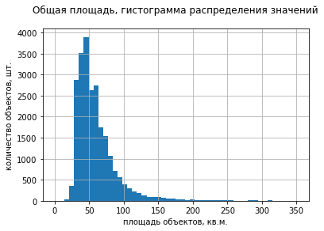

```python
df.hist('total_area', bins=50, range=(0,350))
plt.xlabel('площадь объектов, кв.м.')
plt.ylabel('количество объектов, шт.')
plt.title('Общая площадь, гистограмма распределения значений', pad=20);
```

Рассмотрим те же данные поближе:

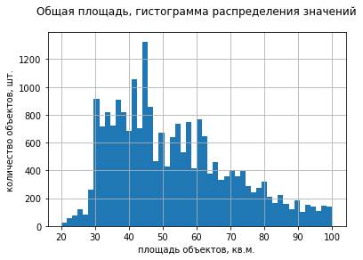

```python
df.hist('total_area', bins=50, range=(20,100))
plt.xlabel('площадь объектов, кв.м.')
plt.ylabel('количество объектов, шт.')
plt.title('Общая площадь, гистограмма распределения значений', pad=20);
```

Посмотрим, на какие именно число призодятся пики значений:

```python
df['total_area'].value_counts().head()
```

```
45.0    419
42.0    383
60.0    347
31.0    346
44.0    345
Name: total_area, dtype: int64
```

Теперь посмотрим на график распределения общей стоимости объектов:

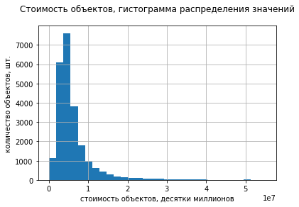

```python
df.hist('last_price', bins=30, range=(0, 55000000))
plt.xlabel('стоимость объектов, десятки миллионов')
plt.ylabel('количество объектов, шт.')
plt.title('Стоимость объектов, гистограмма распределения значений', pad=20);
```

Посмотрим на график в приближении:

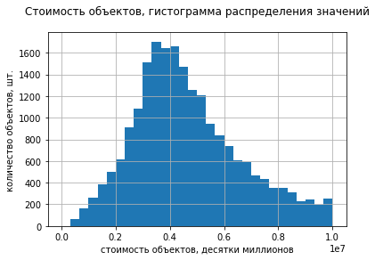

```python
df.hist('last_price', bins=30, range=(0, 10000000))
plt.xlabel('стоимость объектов, десятки миллионов')
plt.ylabel('количество объектов, шт.')
plt.title('Стоимость объектов, гистограмма распределения значений', pad=20);
```

График распределения количества комнат:

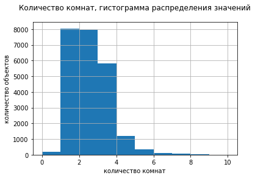

```python
df.hist('rooms', bins=10, range=(0,10))
plt.xlabel('количество комнат')
plt.ylabel('количество объектов')
plt.title('Количество комнат, гистограмма распределения значений', pad=20);
```

Гистограмма распределения высоты потолков:

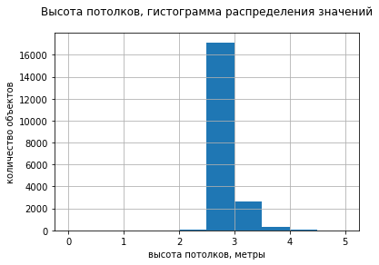

```python
df.hist('ceiling_height', bins=10, range=(0,5))
plt.xlabel('высота потолков, метры')
plt.ylabel('количество объектов')
plt.title('Высота потолков, гистограмма распределения значений', pad=20);
```

**Площадь**: распределение в целом совпадает с ожидаемым (самые многочисленные значения от 30 до 50 кв.м., пик гистограммы приходится на 45 кв.м., затем примерно после 63 кв.м. идёт постепенный спад. Немного неожиданно, что всё-таки довольно много объектов с необычно большой площадью, например, более 100 кв.м.)

**Цена**: выглядит ожидаемой, повторяет логику гистограммы с площадью объектов (самые частые значения примерно от 3 до 5 млн, далее постепенный спад с тянущимся "хвостом" более редких значений)

**Число комнат**: выглядит ожидаемо (самые частые 1, 2-комнатные объекты, реже 3-комнатные, а всё, что больше - встречается гораздо реже)

**Высота потолков**: выглядит ожидаемой (бесспорный лидер - высота от 2.5 до 3 м, реже в диапазоне 3-3.5 м, остальное - скорее исключение из правил)

Особенность: у всех гистограмм есть длинный тянущийся "хвост" (более редкие, выдающиеся от большинства других, значения). Для дальнейшего анализа можно будет его убрать, чтобы точнее рассчитать все средние показатели.

Следующая гистограмма показывает распределение дней от публикации до снятия объявления:

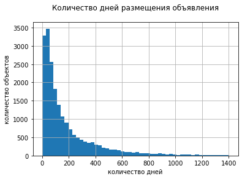

```python
df.hist('days_exposition', bins=50, range=(0,1400))
plt.xlabel('количество дней')
plt.ylabel('количество объектов')
plt.title('Количество дней размещения объявления', pad=20);
```

Посмотрим на этот график в приближении:

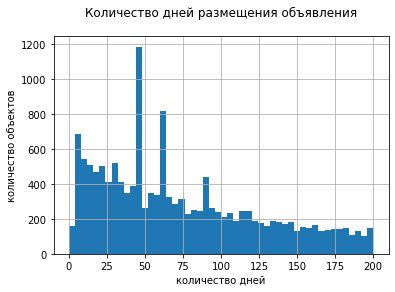

```python
df.hist('days_exposition', bins=50, range=(0,200))
plt.xlabel('количество дней')
plt.ylabel('количество объектов')
plt.title('Количество дней размещения объявления', pad=20);
```

Выясним, какие именно цифры встречаются наиболее часто:

```python
df['days_exposition'].value_counts().head(10)
```

```
45.0    880
60.0    538
7.0     234
30.0    208
90.0    204
4.0     176
3.0     158
5.0     152
14.0    148
9.0     143
Name: days_exposition, dtype: int64
```

Смотрим на квартили, чтобы узнать верхнюю границу нормы:

```python
df['days_exposition'].describe()
```

```
count    20518.000000
mean       180.888634
std        219.727988
min          1.000000
25%         45.000000
50%         95.000000
75%        232.000000
max       1580.000000
Name: days_exposition, dtype: float64
```

Гистограмма говорит о том, что чаще всего **снятие объявления** происходит в течение первых 2-3 месяцев, причём есть выбивающиеся наиболее многочисленные значения: 45, 60, 7, 30 и 90 дней (то есть из этого диапазона можно выделить дополнительно полтора месяца, два месяца, неделю, месяц и три месяца как наиболее часто встречающийся срок продажи). Далее идёт постепенный спад значений, который может тянуться вплоть до 3.5 - 4 лет.

Длинный "хвост" гистограммы влияет на среднее арифметическое: оно показывает, что срок размещения объявления **в среднем** (строка mean в функции describe()) составляет **181 день** (т.е. примерно 6 мес.), тогда как **медиана** (строка 50% в функции describe()) показывает, что в среднем срок размещения объявления составляет **95 дней** (около 3 мес.).

Можно считать, что продажа происходит **быстро**, если она происходит в срок **до 45 дней** (то есть не доходит до первого квартиля, он же отображён самым высоким пиком на гистограмме).

И можно считать, что продажа происходит **необычно долго**, если она занимает **более 513 дней** (это верхняя граница нормы, найденная по формуле: Q3 + 1.5 * IQR) - на первой гистограмме такие значения отображены в виде тянущегося длинного тонкого "хвоста".

Надо иметь ввиду, что данные о продаже в данном случае имеют немного косвенный характер - ведь мы видим информацию о снятии объявления, а не о самой продаже (например иногда снятие объявления говорит об окончании бесплатного показа, но не о продаже).

Как видно по анализу столбца days_exposition, выбивающиеся значения могут оказывать существенное влияние на расчёт средних величин (например, в этом столбце медиана и среднее арифметическое отличаются практически в 2 раза).

Поэтому для дальнейшей работы **уберём редкие и выбивающиеся значения**.

Начнём с общей площади:

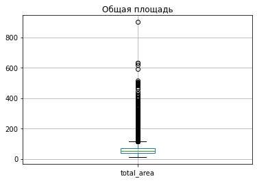

```python
df.boxplot('total_area')
plt.title('Общая площадь');
```

Так было в общих данных:

```python
df['total_area'].describe()
```

```
count    23699.000000
mean        60.348651
std         35.654083
min         12.000000
25%         40.000000
50%         52.000000
75%         69.900000
max        900.000000
Name: total_area, dtype: float64
```

Верхняя граница нормы равна: (69.9 - 40.0) * 1.5 + 69.9 = 114.75 = 115

Но мы уберём выделяющиеся значения не прямо по норме, а скорее визуально по гистограмме, чтобы не отсекать слишком много данных

```python
df_normal = df.query('total_area < 200')
```

Так стало в новом датафрейме:

```python
df_normal['total_area'].describe()
```

```
count    23468.000000
mean        58.155629
std         26.469479
min         12.000000
25%         40.000000
50%         51.900000
75%         68.900000
max        199.200000
Name: total_area, dtype: float64
```

Отслеживаем, сколько данных у нас остаётся в датафрейме (чтобы не убрать слишком много):

```python
len(df_normal)
```

```
23468
```

Теперь рассмотрим общую стоимость объектов:

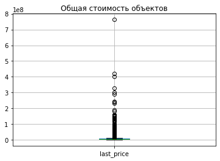

```python
df.boxplot('last_price')
plt.title('Общая стоимость объектов');
```

Так было в общих данных:

```python
df['last_price'].describe()
```

```
count    2.369900e+04
mean     6.541549e+06
std      1.088701e+07
min      1.219000e+04
25%      3.400000e+06
50%      4.650000e+06
75%      6.800000e+06
max      7.630000e+08
Name: last_price, dtype: float64
```

Верхняя граница нормы равна (6.8 - 3.4) * 1.5 + 6.8 = 11.9 млн Но мы, ориентируясь на гистограмму, уберём опять только сильно выбивающиеся значения:

```python
df_normal = df_normal.query('last_price < 40000000')
```

Так стало в новом датафрейме:

```python
df_normal['last_price'].describe()
```

```
count    2.337500e+04
mean     5.790621e+06
std      4.305562e+06
min      1.219000e+04
25%      3.400000e+06
50%      4.600000e+06
75%      6.650000e+06
max      3.999000e+07
Name: last_price, dtype: float64
```

Продолжаем отслеживать количество строк в датафрейме:

```python
len(df_normal)
```

```
23375
```

Рассмотрим количество комнат:

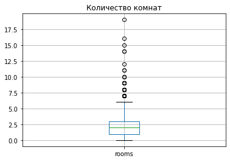

```python
df.boxplot('rooms')
plt.title('Количество комнат');
```

Так было:

```python
df['rooms'].describe()
```

```
count    23699.000000
mean         2.070636
std          1.078405
min          0.000000
25%          1.000000
50%          2.000000
75%          3.000000
max         19.000000
Name: rooms, dtype: float64
```

Верхняя граница нормы равна (3 - 1)* 1.5 +3 = 6

```python
df_normal = df_normal.query('rooms < 6')
```

Так стало:

```python
df_normal['rooms'].describe()
```

```
count    23291.000000
mean         2.013181
std          0.956884
min          0.000000
25%          1.000000
50%          2.000000
75%          3.000000
max          5.000000
Name: rooms, dtype: float64
```

Отслеживаем количество строк в датафрейме после очередных изменений:

```python
len(df_normal)
```

```
23291
```

Рассмотрим высоту потолков:

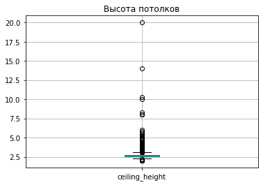

```python
df.boxplot('ceiling_height')
plt.title('Высота потолков');
```

Так было в общем датафрейме:

```python
df['ceiling_height'].describe()
```

```
count    20237.000000
mean         2.701709
std          0.307110
min          2.000000
25%          2.550000
50%          2.600000
75%          2.750000
max         20.000000
Name: ceiling_height, dtype: float64
```

Верхняя граница нормы (2.75 - 2.55)* 1.5 + 2.75 =3.05 Но уберём опять не прямо по границе, чтобы не срезать слишком много данных. Всё-таки в центре Петербурга может быть много исторических зданий с высокими потолками:

```python
df_normal = df_normal.loc[(df_normal['ceiling_height'].isna()) | (df_normal['ceiling_height'] < 4)]
```

Так стало в новом датафрейме:

```python
df_normal['ceiling_height'].describe()
```

```
count    19825.000000
mean         2.685140
std          0.215898
min          2.000000
25%          2.550000
50%          2.600000
75%          2.750000
max          3.980000
Name: ceiling_height, dtype: float64
```

Фиксируем количество строк после изменений:

```python
len(df_normal)
```

```
23221
```

Рассмотрим срок размещения объявления:

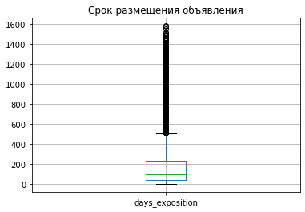

```python
df.boxplot('days_exposition')
plt.title('Срок размещения объявления');
```

Так было в общих данных:

```python
df['days_exposition'].describe()
```

```
count    20518.000000
mean       180.888634
std        219.727988
min          1.000000
25%         45.000000
50%         95.000000
75%        232.000000
max       1580.000000
Name: days_exposition, dtype: float64
```

Верхняя граница нормы: (232 - 45) * 1.5 + 232 = 512.5 = 513 Но опять отбросим скорее визуально по гистограмме, чтобы не выкинуть слишком много данных:

```python
df_normal = df_normal.loc[(df_normal['days_exposition'].isna()) | (df_normal['days_exposition'] < 1000)]
```

Так стало в новом датафрейме:

```python
df_normal['days_exposition'].describe()
```

```
count    19899.000000
mean       165.659078
std        185.993092
min          1.000000
25%         44.000000
50%         92.000000
75%        218.000000
max        999.000000
Name: days_exposition, dtype: float64
```

Количество строк в новом датафрейме после всех изменений:

```python
len(df_normal)
```

```
22957
```

Сколько строк убрано:

```python
len(df) - len(df_normal)
```

```
742
```

Сколько процентов составляет количество убранных строк от общего объёма данных:

```python
(len(df) - len(df_normal)) / len(df) * 100
```

```
3.130933794674881
```

**Таким образом** мы отсекли все выбивающиеся значения в столбцах с данными о площади, цене, числе комнат, высоте потолков и времени продажи квартиры и **сохранили отфильтрованные данные в df_normal**.

В каждом из этих столбцов были значения, выходящие за пределы нормы. После изменений везде уменьшились средние значения (mean) и стандартные отклонения (std), что говорит о том, что разброс данных стал ближе к среднему (т.е. нормальному распределению).

Теперь переходим к изучению вопроса о том, какие факторы больше всего влияют на стоимость квартиры.

```python
df_normal['last_price'].corr(df_normal['total_area']) #влияние площади объекта на общую цену
```

```
0.7719278962835333
```

```python
df_normal['price_per_square_meter'].corr(df_normal['total_area']) #влияние площади объекта на цену за кв.м.
```

```
0.18239231298347716
```

```python
df_normal['last_price'].corr(df_normal['rooms']) #влияние количества комнат на общую цену
```

```
0.4663336768369024
```

```python
df_normal['price_per_square_meter'].corr(df_normal['rooms']) #влияние количества комнат на цену за кв.м.
```

```
-0.053597665139295196
```

```python
df_normal['last_price'].corr(df_normal['city_centers_nearest']) #влияние удалённости от центра на общую цену
```

```
-0.3349687799318525
```

```python
df_normal['price_per_square_meter'].corr(df_normal['city_centers_nearest']) #влияние удалённости от центра на цену за кв.м.
```

```
-0.37713060152099576
```

Коэффициент корреляции Пирсона показывает:

- сильнее всего общая стоимость объекта зависит от **общей площади**, причём зависимость эта положительная (чем больше площадь, тем выше и цена) и достаточно ощутимая
- влияние площади объекта на цену за кв.м. близко к нулю, что логично (это нечто из разряда "масло масляное")
- зависимость цены от **числа комнат** тоже выражена положительным коэффициентом (больше комнат - больше цена), но эта зависимость выражена слабее
- влияние количества комнат на цену за кв.м. гораздо слабее и корреляция отрицательная (больше комнат - ниже цена за кв.м.)
- **удалённость от центра** оказывает слабое влияние и на общую цену, и на цену за кв.м. и оно выражено отрицательным коэффициентом (чем больше удалённость от центра, тем ниже цена)

Столбчатый график показывает зависимость общей цены объекта от категории этажа, на котором объект находится:

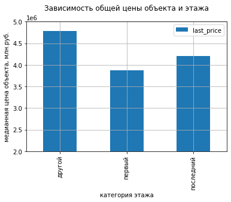

```python
(df_normal
     .pivot_table(index='object_floor', values='last_price', aggfunc='median')
     .plot(kind='bar', ylim=(2000000, 5000000), grid=True))
plt.xlabel('категория этажа')
plt.ylabel('медианная цена объекта, млн.руб.')
plt.title('Зависимость общей цены объекта и этажа', pad=20);
```

Столбчатый график показывает зависимость цены за кв.м. объекта от категории этажа, на котором объект находится:

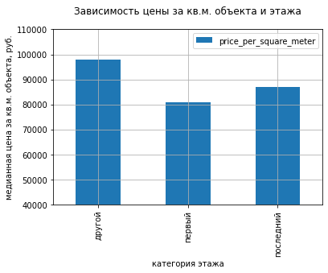

```python
(df_normal
     .pivot_table(index='object_floor', values='price_per_square_meter', aggfunc='median')
     .plot(kind='bar', ylim=(40000, 110000), grid=True))
plt.xlabel('категория этажа')
plt.ylabel('медианная цена за кв.м. объекта, руб.')
plt.title('Зависимость цены за кв.м. объекта и этажа', pad=20);
```

Что касается этажей, на которых расположены объекты:

- самая низкая стоимость у квартир **на первых этажах**
- чуть лучше дела обстоят у квартир, расположенных **на последних этажах**
- и лучше всех дела обстоят у квартир на любых **других этажах**

Графики показывают, что этот эффект наблюдается и в расчётах с общей ценой объекта, и с ценой за квадратный метр.

Столбчатый график показывает медианное значение общей цены в зависимости от дня недели, когда было размещено объявление:

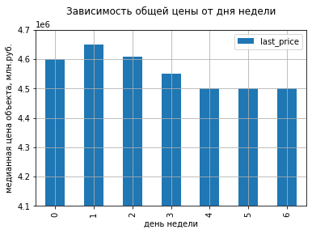

```python
(df_normal
    .pivot_table(index='day_of_first_exposition', values='last_price', aggfunc='median')
    .plot(kind='bar', ylim=(4100000, 4700000), grid=True))
plt.xlabel('день недели')
plt.ylabel('медианная цена объекта, млн.руб.')
plt.title('Зависимость общей цены от дня недели', pad=20);
```

Столбчатый график показывает медианное значение цены за кв.м. в зависимости от дня недели, когда было размещено объявление:

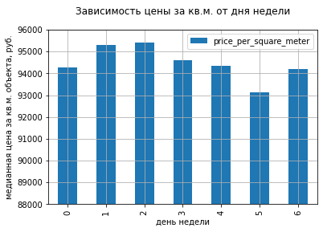

```python
(df_normal
    .pivot_table(index='day_of_first_exposition', values='price_per_square_meter', aggfunc='median')
    .plot(kind='bar', ylim=(88000, 96000), grid=True))
plt.xlabel('день недели')
plt.ylabel('медианная цена за кв.м. объекта, руб.')
plt.title('Зависимость цены за кв.м. от дня недели', pad=20);
```

Что касается дня размещения объявления, то здесь не всё так однозначно. **Первый график** (зависимость дня подачи объявления и **общей цены объекта**) говорит о том, что:

- самые удачные дни для размещения объявления это вторник, среда, понедельник
- четверг показывает менее удачный результат
- и самая низкая цена оказывается у объектов, объявления о продаже которых размещали в пятницу, субботу и воскресенье

Если же посмотреть на **второй график** (зависимость дня подачи объявления и **цены за квадратный метр**), то мы увидим:

- самая высокая цена у объектов, объявления о которых разместили в среду и вторник
- чуть меньшие результаты приходятся на четверг, пятницу, понедельник и воскресенье
- самый низкий показатель здесь у объектов, информацию о которых разместили в субботу

Итого: некоторая зависимость цены от дня размещения объявления есть, и она отличается в зависимости от того, через какой показатель смотреть: через общую цену объекта или цену за квадратный метр. **Общий вывод** у этих данных можно представить в виде условного рейтинга дней, от более удачных для размещения объявления к менее удачным:

- лучшие дни - будние: вторник, среда
- относительно удачные: понедельник, четверг, пятница
- менее удачные: выходные.

Возможно, корреляция носит случайный характер или она связана с **третьим фактором**. Например, могу предположить, что в выходные дни часто выкладывают объявления обычные люди (а не риэлторы), поэтому они, не обладая профессиональными знаниями и возможностями в этой сфере, продают свои объекты по чуть более низкой цене, чем люди, которые занимаются продажей недвижимости профессионально. Либо ещё можно предположить, что объявлений в выходные в принципе размещается больше, и поэтому на каждое отдельно взятое из них обращается меньше внимания (меньше просмотров), что в итоге сказывается и на цене продажи. Разобраться в этом поможет гистограмма распределения значений.

Гистограмма распределения значений:

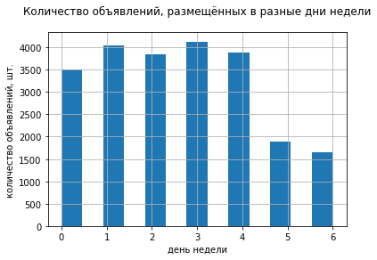

```python
df_normal.hist('day_of_first_exposition', bins=13)
plt.xlabel('день недели')
plt.ylabel('количество объявлений, шт.')
plt.title('Количество объявлений, размещённых в разные дни недели', pad=20);
```

Судя по этому графику, моя последняя гипотеза не подтвердилась. Больше всего объявлений размещается по четвергам, вторникам, пятницам, средам, понедельникам (в порядке от большего к меньшему), а в выходные объявлений размещается меньше всего. Поэтому получается что эта корреляция связана скорее с **количеством поданых объявлений** в эти дни, а не с самими днями недели.

Столбчатый график показывает медианное значение общей цены в зависимости от месяца, когда было размещено объявление:

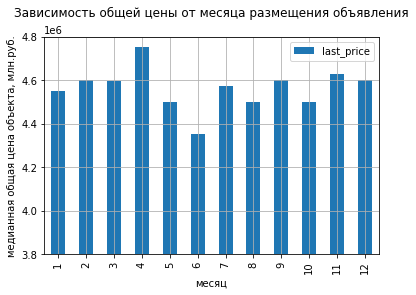

```python
(df_normal
     .pivot_table(index='month_of_first_exposition', values='last_price', aggfunc='median')
     .plot(kind='bar', ylim=(3800000, 4800000), grid=True))
plt.xlabel('месяц')
plt.ylabel('медианная общая цена объекта, млн.руб.')
plt.title('Зависимость общей цены от месяца размещения объявления', pad=20);
```

Столбчатый график показывает медианное значение цены за кв.м. в зависимости от месяца, когда было размещено объявление:

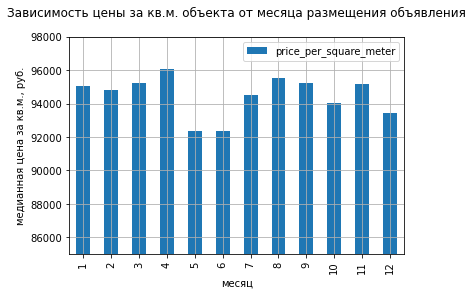

```python
(df_normal
     .pivot_table(index='month_of_first_exposition', values='price_per_square_meter', aggfunc='median')
     .plot(kind='bar', ylim=(85000, 98000), grid=True))
plt.xlabel('месяц')
plt.ylabel('медианная цена за кв.м., руб.')
plt.title('Зависимость цены за кв.м. объекта от месяца размещения объявления', pad=20);
```

Рассмотрим зависимость **общей цены объекта** и месяца размещения объявления.

Можно выделить несколько групп:

- самые неудачные продажи: июнь
- средние показатели у месяцев: май, август, октябрь (равны между собой)
- более удачные показатели у месяцев: январь, июль, февраль, март, сентябрь, декабрь
- и лучше всего у месяцев: ноябрь, и абсолютный лидер - апрель.

Если рассмотреть зависимость **цены за квадратный метр** и месяца, то мы увидим:

- совпадающий анти-лидер рейтинга: июнь, и наравне с ним май
- на следующей ступеньке декабрь и недалеко от него октябрь
- июль, февраль, январь, март, ноябрь, сентябрь показывают постепенный рост показателя
- и лучшие показатели у августа и апреля.

Рассмотрим сразу и гистограмму распределения значений, чтобы понять, имеет ли место в зависимости цены и месяца связь с третьим фактором в виде количества поданых объявлений (как это было случае с днями).

Гистограмма распределения значений: сколько объявлений подано в каждый из месяцев:

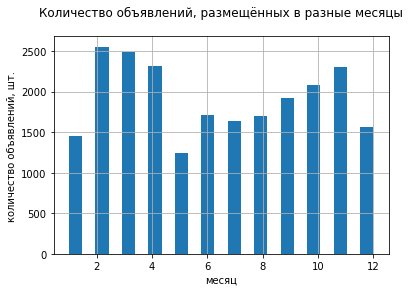

```python
df_normal.hist('month_of_first_exposition', bins=23)
plt.xlabel('месяц')
plt.ylabel('количество объявлений, шт.')
plt.title('Количество объявлений, размещённых в разные месяцы', pad=20);
```

Здесь график распределения количества объявлений по месяцам не так похож на найденный ранее "рейтинг" месяцев

- анти-лидер рейтинга здесь май (а не июнь)
- на следующей ступени январь, затем декабрь, июль, июнь, август
- далее возрастающие значения показывают сентябрь, октябрь, ноябрь, апрель
- и в лидерах находятся март и февраль

Какие **выводы** можно сделать.

- зависимость между ценой и месяцем подачи объявления не похожа на зависимость цены и дня недели подачи объявления, она имеет другой характер.
- на рынок недвижимости (и цену продажи объекта) влияет сезонный фактор: есть более удачные и менее удачные месяцы для размещения объявления.

Данные говорят о том, что:

- **июнь и май** - **худшее время** для того, чтобы разместить объявление о продаже и рассчитывать на высокую цену (хотя в июне подают не так уж мало объявлений). Вероятно, это связано с сезоном отпусков, и оттого количество потенциальных покупателей невелико.
- не слишком удачные в этом плане месяцы: октябрь, январь, июль
- более-менее благополучные: февраль, март, сентябрь, декабрь
- удачные: ноябрь, август
- **лучшее время** для продажи: **апрель**

Столбчатый график показывает медианное значение общей цены в зависимости от года, когда было размещено объявление:

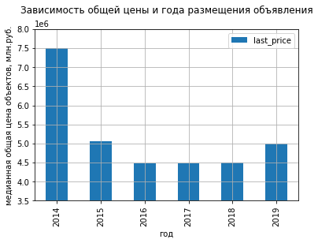

```python
(df_normal
    .pivot_table(index='year_of_first_exposition', values='last_price', aggfunc='median')
    .plot(kind='bar', ylim=(3500000,8000000), grid=True))
plt.xlabel('год')
plt.ylabel('медианная общая цена объектов, млн.руб.')
plt.title('Зависимость общей цены и года размещения объявления', pad=20);
```

Столбчатый график показывает медианное значение цены за кв.м. в зависимости от года, когда было размещено объявление:

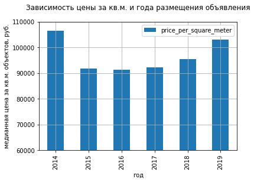

```python
(df_normal
    .pivot_table(index='year_of_first_exposition', values='price_per_square_meter', aggfunc='median')
    .plot(kind='bar', ylim=(60000,110000), grid=True))
plt.xlabel('год')
plt.ylabel('медианная цена за кв.м. объектов, руб.')
plt.title('Зависимость цены за кв.м. и года размещения объявления', pad=20);
```

Зависимость цены от года размещения объявления различается в зависимости от того, через какой параметр смотреть на эту зависимость.

График соотношения **общей цены** и года показывает:

- резкое падение от 2014 года к 2015
- продолжение падения к 2016, но более плавное
- одинаковые значения в 2016, 2017 и 2018 годах
- рост к 2019 году

График соотношения **цены за квадратный метр** и года показывает:

- резкое падение от 2014 к 2015 году
- практически незаметное снижение от 2015 к 2016 году
- начало плавного постепенного роста от 2016 к 2017 году
- усиливающийся рост от 2017 к 2019 году

Гистограмма распределения значений - сколько объявлений размещено в каждый год:

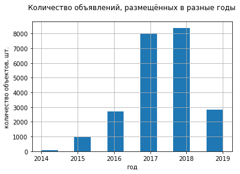

```python
df_normal.hist('year_of_first_exposition', bins=11)
plt.xlabel('год')
plt.ylabel('количество объектов, шт.')
plt.title('Количество объявлений, размещённых в разные годы', pad=20);
```

Если взглянуть на гистограмму распределения значений, то становится понятней причина возникновения такого резкого падения в 2014 и 2015 годах: данных за эти годы на порядок меньше даных за 2017 и 2018 год. Поэтому на малой выборке виден такой резкий перепад. Несколько объектов по высокой цене (например, в центре города), не "уравновешенные" многочисленными другими объектами, могли оказать такое существенное влияние на показатель медианной цены.

В целом **вывод** о характере взаимосвязи цены и года размещения объявления звучит следующим образом:

- имеет место резкое падение цен (от самых значительных) в 2014 к 2015 году (но здесь надо учесть, что данных за 2014 год крайне мало)
- в 2016 году самые небольшие значения цены (и общей, и за кв.м.)
- далее в 2016-2017 данные показывают примерно одинаковые значения
- и с 2018 к 2019 цена растёт (а цена за кв.м. показывает тенденцию роста цен ещё раньше, с 2017 года)

Теперь находим 10 населённых пунктов с наибольшим числом объявлений:

```python
df_normal['locality_name'].value_counts().head(10)
```

```
Санкт-Петербург      15082
посёлок Мурино         517
посёлок Шушары         436
Всеволожск             392
Пушкин                 356
Колпино                335
посёлок Парголово      325
Гатчина                306
деревня Кудрово        294
Выборг                 234
Name: locality_name, dtype: int64
```

Создаём новый датафрейм для дальнейшей работы:

```python
top_10_list = ['Санкт-Петербург','посёлок Мурино','посёлок Шушары','Всеволожск','Пушкин','Колпино',
               'посёлок Парголово','Гатчина','деревня Кудрово','Выборг']
df_top_10 = df_normal.query('locality_name in @top_10_list')
```

Проверяем, смотрим описание данных, все 10 пунктов на месте:

```python
df_top_10['locality_name'].describe()
```

```
count               18277
unique                 10
top       Санкт-Петербург
freq                15082
Name: locality_name, dtype: object
```

Средняя цена за кв.м. в этих 10 населённых пунктах (в порядке возрастания):

```python
top_10_table = (df_top_10.pivot_table(index='locality_name', values='price_per_square_meter')
                         .sort_values(by='price_per_square_meter'))
top_10_table.reset_index(inplace= True)
top_10_table.columns=['Населённый пункт', 'Цена за кв.м.']
top_10_table
```

|  | Населённый пункт | Цена за кв.м. |
| --- | --- | --- |
| 0 | Выборг | 58132.311966 |
| 1 | Всеволожск | 68596.375000 |
| 2 | Гатчина | 68799.176471 |
| 3 | Колпино | 75279.280597 |
| 4 | посёлок Шушары | 78615.348624 |
| 5 | посёлок Мурино | 85867.390716 |
| 6 | посёлок Парголово | 90259.320000 |
| 7 | деревня Кудрово | 92421.074830 |
| 8 | Пушкин | 102900.952247 |
| 9 | Санкт-Петербург | 111444.526323 |

То же самое в виде линейчатого графика:

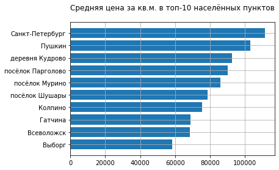

```python
x = top_10_table['Цена за кв.м.']
y = top_10_table['Населённый пункт']

plt.barh(y,x)
plt.grid()

plt.title('Средняя цена за кв.м. в топ-10 населённых пунктов', pad=20);
```

Среди **10 населённых пунктов** с наибольшим числом объявлений можно выделить:

- населённые пункты с самой **высокой** средней ценой за квадратный метр (т.е.стоимостью жилья):
  - Санкт-Петербург
  - Пушкин
  - деревня Кудрово
- населённые пункты с самой **низкой** стоимостью жилья:
  - Выборг
  - Всеволожск
  - Гатчина

Выделяем квартиры в Санкт-Петербурге:

```python
df_spb = df_normal.loc[df_normal['locality_name'] == 'Санкт-Петербург']
```

Переводим метры в километры:

```python
df_spb['city_centers_nearest_km'] = df_spb['city_centers_nearest'] * 0.001
```

Переводим в целые числа:

```python
df_spb['city_centers_nearest_km'] = df_spb['city_centers_nearest_km'].dropna().astype(int)
```

Столбчатый график показывает, как меняется среднее значение общей цены в зависимости от удалённости от центра (по км):

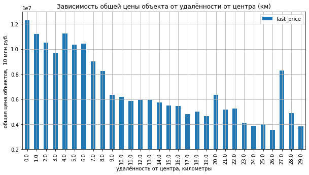

```python
(df_spb
.pivot_table(index='city_centers_nearest_km', values='last_price').sort_values(by='city_centers_nearest_km')
.plot(kind='bar', ylim=(2000000, 13000000), grid=True, figsize=(10, 5)))
plt.xlabel('удалённость от центра, километры')
plt.ylabel('общая цена объектов,  10 млн.руб.')
plt.title('Зависимость общей цены объекта от удалённости от центра (км)');
```

Столбчатый график показывает, как меняется среднее значение цены за кв.м. в зависимости от удалённости от центра (по км):

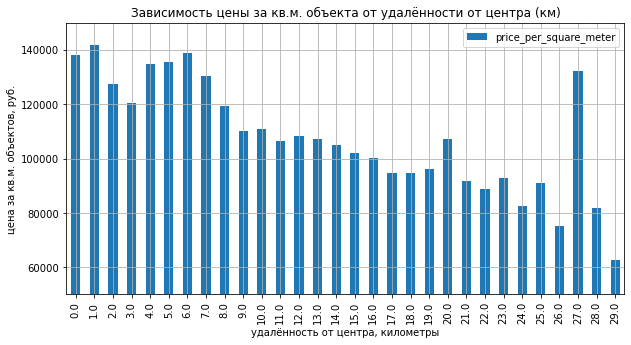

```python
(df_spb
.pivot_table(index='city_centers_nearest_km', values='price_per_square_meter').sort_values(by='city_centers_nearest_km')
.plot(kind='bar', ylim=(50000, 150000), grid=True, figsize=(10, 5)))
plt.xlabel('удалённость от центра, километры')
plt.ylabel('цена за кв.м. объектов, руб.')
plt.title('Зависимость цены за кв.м. объекта от удалённости от центра (км)');
```

**Первый график** показывает среднюю стоимость **всего объекта** для каждого километра удалённости от центра.

**Второй график** показывает среднюю стоимость **квадратного метра** для каждого километра.

У них есть вполне предсказуемая **общая тенденция**: чем ближе к центру, тем цена выше (это касается и общей цены, и цены за кв.м.).

Судя по ним, **центральная зона** находится в диапазоне от 0 до 8 км включительно (здесь наиболее высокие значения на обоих графиках).

Интересная особенность: кажется, на 20 и 27 километрах от центра есть какие-то хорошие районы (цена на обоих графиках выше). Возможно, это связано с какими-то историческими местами (например, Петергоф). Можно проверить это предположение на гистограмме.

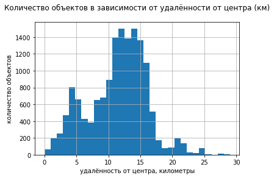

```python
df_spb.hist('city_centers_nearest_km', bins=30)
plt.xlabel('удалённость от центра, километры')
plt.ylabel('количество объектов')
plt.title('Количество объектов в зависимости от удалённости от центра (км)', pad=20);
```

Как мы видим, на 27 км практически нет объектов, значит, скачок цены происходит вследствие малой выборки, а не каких-то объективных географических и инфраструктурных причин. Значит, Петергоф тут не при чём :-)